# Titanic_EDA_Project_Ridhi_Kalsi

```python
import zipfile

with zipfile.ZipFile('titanic.zip', 'r') as zip_ref:
    zip_ref.extractall('titanic')
```

```python
import warnings
warnings.filterwarnings('ignore')

import pandas as pd

df = pd.read_csv('titanic/train.csv')
df.head()
```

|  | PassengerId | Survived | Pclass | Name | Sex | Age | SibSp | Parch | Ticket | Fare | Cabin | Embarked |
| --- | --- | --- | --- | --- | --- | --- | --- | --- | --- | --- | --- | --- |
| 0 | 1 | 0 | 3 | Braund, Mr. Owen Harris | male | 22.0 | 1 | 0 | A/5 21171 | 7.2500 | NaN | S |
| 1 | 2 | 1 | 1 | Cumings, Mrs. John Bradley (Florence Briggs Th... | female | 38.0 | 1 | 0 | PC 17599 | 71.2833 | C85 | C |
| 2 | 3 | 1 | 3 | Heikkinen, Miss. Laina | female | 26.0 | 0 | 0 | STON/O2. 3101282 | 7.9250 | NaN | S |
| 3 | 4 | 1 | 1 | Futrelle, Mrs. Jacques Heath (Lily May Peel) | female | 35.0 | 1 | 0 | 113803 | 53.1000 | C123 | S |
| 4 | 5 | 0 | 3 | Allen, Mr. William Henry | male | 35.0 | 0 | 0 | 373450 | 8.0500 | NaN | S |

### 📊 Data Summary

- **Total Rows**: 891 passengers
- **Missing Values**:
  - `Age`: 177 missing → will be filled with **median** to preserve distribution.
  - `Cabin`: 687 missing → too many missing values, so we'll **drop this column**.
  - `Embarked`: 2 missing → easy to fill with **most frequent value** (mode).

### 🔍 Data Overview and Missing Value Inspection

We begin by exploring the dataset structure, data types, basic statistics, and checking for any missing values.

```python
# Check data types and non-null counts
df.info()

# Basic statistical summary of numeric columns
df.describe()

# Count missing values in each column
df.isnull().sum()
```

```
<class 'pandas.core.frame.DataFrame'>
RangeIndex: 891 entries, 0 to 890
Data columns (total 12 columns):
 #   Column       Non-Null Count  Dtype
---  ------       --------------  -----
 0   PassengerId  891 non-null    int64
 1   Survived     891 non-null    int64
 2   Pclass       891 non-null    int64
 3   Name         891 non-null    object
 4   Sex          891 non-null    object
 5   Age          714 non-null    float64
 6   SibSp        891 non-null    int64
 7   Parch        891 non-null    int64
 8   Ticket       891 non-null    object
 9   Fare         891 non-null    float64
 10  Cabin        204 non-null    object
 11  Embarked     889 non-null    object
dtypes: float64(2), int64(5), object(5)
memory usage: 83.7+ KB
```

|  | 0 |
| --- | --- |
| PassengerId | 0 |
| Survived | 0 |
| Pclass | 0 |
| Name | 0 |
| Sex | 0 |
| Age | 177 |
| SibSp | 0 |
| Parch | 0 |
| Ticket | 0 |
| Fare | 0 |
| Cabin | 687 |
| Embarked | 2 |

**dtype:** int64

```python
# Fill missing Age with median
df['Age'].fillna(df['Age'].median(), inplace=True)

# Fill missing Embarked with mode
df['Embarked'].fillna(df['Embarked'].mode()[0], inplace=True)

# Drop Cabin column (too many missing values)
if 'Cabin' in df.columns:
    df.drop('Cabin', axis=1, inplace=True)
```

Before performing any detailed analysis, it's essential to deal with missing values.

- **Age**: Missing values are filled with the median to preserve the distribution.
- **Embarked**: Filled with the most frequent value (mode), which is usually safe for categorical columns.
- **Cabin**: Dropped due to excessive missing data and low analytical importance.

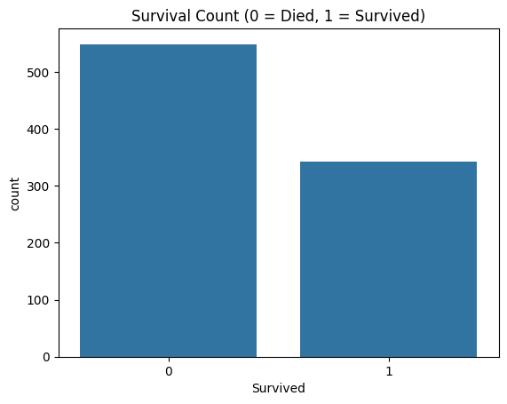

```python
import seaborn as sns
import matplotlib.pyplot as plt

sns.countplot(x='Survived', data=df)
plt.title("Survival Count (0 = Died, 1 = Survived)")
plt.show()
```

**Survived**

The dataset is imbalanced, with more passengers who did not survive (label 0) compared to those who did (label 1).

Around 62% of passengers did not survive the Titanic disaster.

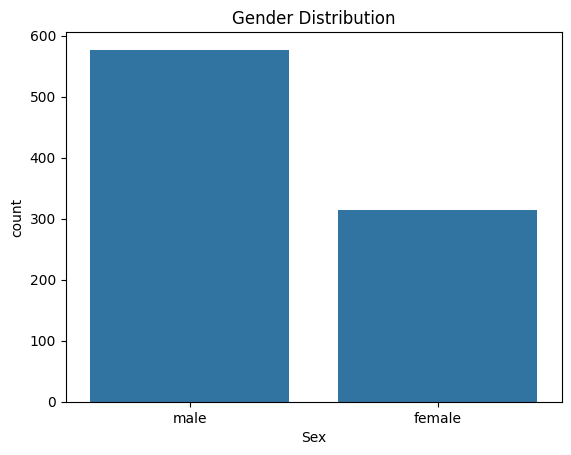

```python
sns.countplot(x='Sex', data=df)
plt.title("Gender Distribution")
plt.show()
```

**Sex**

There are significantly more males than females onboard (roughly 65% male, 35% female).

This imbalance may affect survival trends when grouped by gender.

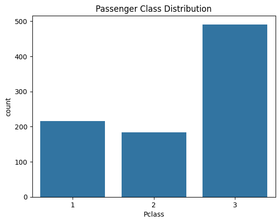

```python
sns.countplot(x='Pclass', data=df)
plt.title("Passenger Class Distribution")
plt.show()
```

**Pclass (Passenger Class)**

Most passengers belonged to the 3rd class, followed by 1st and 2nd class.

This may reflect socio-economic status and could be correlated with survival.

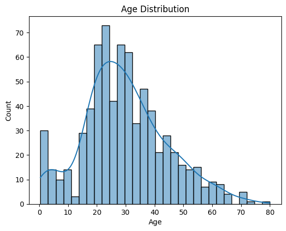

```python
sns.histplot(data=df, x='Age', bins=30, kde=True)
plt.title("Age Distribution")
plt.show()
```

**Age**

The majority of passengers were between 20–40 years old.

There is a visible range of children and elderly passengers, but they’re fewer in comparison.

The age distribution is slightly right-skewed (more younger passengers).

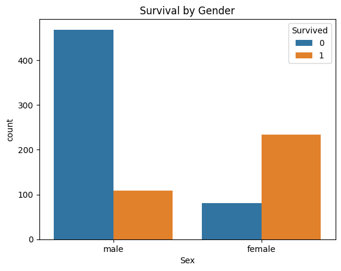

```python
sns.countplot(x='Sex', hue='Survived', data=df)
plt.title("Survival by Gender")
plt.show()
```

A much higher proportion of females survived compared to males.

This supports the historical "women and children first" evacuation strategy.

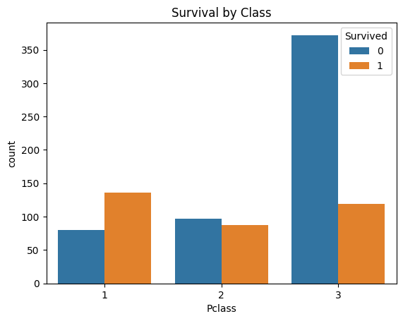

```python
sns.countplot(x='Pclass', hue='Survived', data=df)
plt.title("Survival by Class")
plt.show()
```

Passengers in 1st class had the highest survival rate, while those in 3rd class had the lowest.

Higher-class passengers had better access to lifeboats.

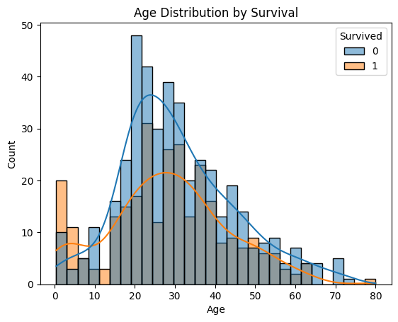

```python
sns.histplot(data=df, x='Age', hue='Survived', bins=30, kde=True)
plt.title("Age Distribution by Survival")
plt.show()
```

There’s no strong age-based survival pattern, but children (under 10) seem to have slightly higher survival.

Adults aged 20–40 show both high survival and non-survival — likely influenced by gender/class.

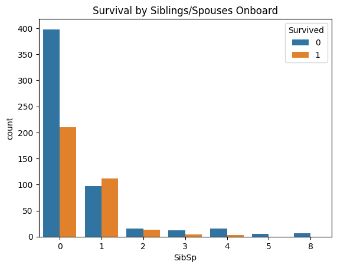

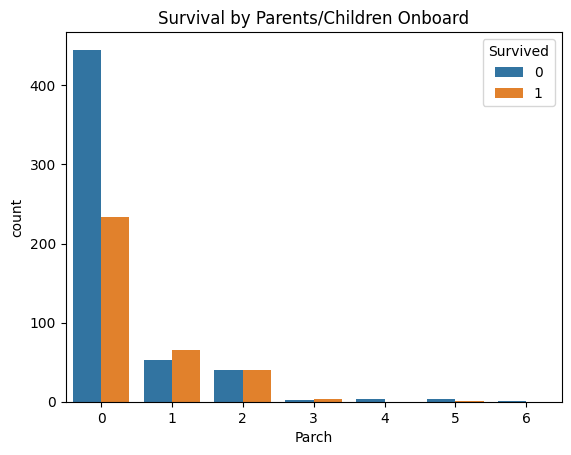

```python
sns.countplot(x='SibSp', hue='Survived', data=df)
plt.title("Survival by Siblings/Spouses Onboard")
plt.show()

sns.countplot(x='Parch', hue='Survived', data=df)
plt.title("Survival by Parents/Children Onboard")
plt.show()
```

Passengers with 1–2 family members had better survival than those alone or with many relatives.

Being alone or in very large groups may have reduced chances of survival.

```python
df_corr = df.copy()

# Map categorical variables to numbers
df_corr['Sex'] = df_corr['Sex'].map({'male': 0, 'female': 1})
df_corr['Embarked'] = df_corr['Embarked'].map({'S': 0, 'C': 1, 'Q': 2})

# Drop irrelevant text columns
df_corr.drop(['Name', 'Ticket', 'Cabin'], axis=1, inplace=True)
```

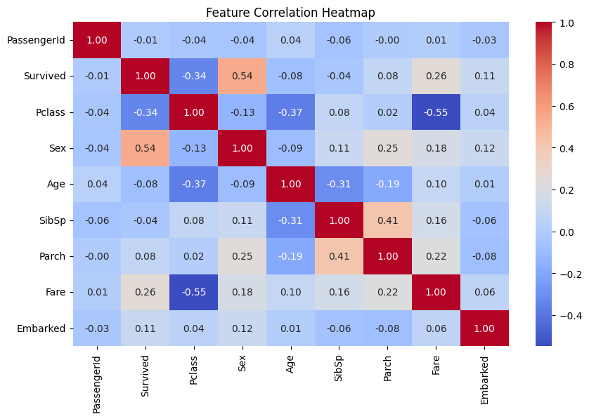

```python
plt.figure(figsize=(10, 6))
sns.heatmap(df_corr.corr(), annot=True, cmap='coolwarm', fmt='.2f')
plt.title("Feature Correlation Heatmap")
plt.show()
```

Sex (female) is strongly correlated with survival (~0.54)

Pclass is negatively correlated (higher class → more survival)

Fare has a positive correlation — people who paid more survived more (likely 1st class)

```python
df['Cabin'] = df['Cabin'].fillna('Unknown')  # or drop if not used
df['Embarked'] = df['Embarked'].fillna(df['Embarked'].mode()[0])
df['Age'] = df['Age'].fillna(df['Age'].median())
```

## 🎯 Final Key Takeaways:

This EDA helped uncover meaningful insights from the Titanic dataset using Python, Pandas, Matplotlib, and Seaborn.